# Clustering - Cereals Dataset

```python
import pandas as pd
import numpy as np
```

### Reading data

```python
cereals = pd.read_csv("Cereals.csv")
cereals.head()
```

|  | name | calories | protein | fat | sodium | fiber | carbo | sugars | potass | vitamins | shelf | weight | cups | rating |
| --- | --- | --- | --- | --- | --- | --- | --- | --- | --- | --- | --- | --- | --- | --- |
| 0 | 100%_Bran | 70 | 4 | 1 | 130 | 10.0 | 5.0 | 6.0 | 280.0 | 25 | 3 | 1.0 | 0.33 | 68.402973 |
| 1 | 100%_Natural_Bran | 120 | 3 | 5 | 15 | 2.0 | 8.0 | 8.0 | 135.0 | 0 | 3 | 1.0 | 1.00 | 33.983679 |
| 2 | All-Bran | 70 | 4 | 1 | 260 | 9.0 | 7.0 | 5.0 | 320.0 | 25 | 3 | 1.0 | 0.33 | 59.425505 |
| 3 | All-Bran_with_Extra_Fiber | 50 | 4 | 0 | 140 | 14.0 | 8.0 | 0.0 | 330.0 | 25 | 3 | 1.0 | 0.50 | 93.704912 |
| 4 | Almond_Delight | 110 | 2 | 2 | 200 | 1.0 | 14.0 | 8.0 | NaN | 25 | 3 | 1.0 | 0.75 | 34.384843 |

### Aggregating "name", "shelf" and "rating" to make labels

```python
cereals['label'] = cereals['name']+ ' (' + cereals['shelf'].astype(str) + " - " + round(cereals['rating'],2).astype(str) + ')'
cereals.drop(['name','shelf','rating'], axis=1, inplace=True)
```

# Data Exploration

```python
cereals.head()
```

|  | calories | protein | fat | sodium | fiber | carbo | sugars | potass | vitamins | weight | cups | label |
| --- | --- | --- | --- | --- | --- | --- | --- | --- | --- | --- | --- | --- |
| 0 | 70 | 4 | 1 | 130 | 10.0 | 5.0 | 6.0 | 280.0 | 25 | 1.0 | 0.33 | 100%_Bran (3 - 68.4) |
| 1 | 120 | 3 | 5 | 15 | 2.0 | 8.0 | 8.0 | 135.0 | 0 | 1.0 | 1.00 | 100%_Natural_Bran (3 - 33.98) |
| 2 | 70 | 4 | 1 | 260 | 9.0 | 7.0 | 5.0 | 320.0 | 25 | 1.0 | 0.33 | All-Bran (3 - 59.43) |
| 3 | 50 | 4 | 0 | 140 | 14.0 | 8.0 | 0.0 | 330.0 | 25 | 1.0 | 0.50 | All-Bran_with_Extra_Fiber (3 - 93.7) |
| 4 | 110 | 2 | 2 | 200 | 1.0 | 14.0 | 8.0 | NaN | 25 | 1.0 | 0.75 | Almond_Delight (3 - 34.38) |

### Check summary statistics

```python
cereals.describe()
```

|  | calories | protein | fat | sodium | fiber | carbo | sugars | potass | vitamins | weight | cups |
| --- | --- | --- | --- | --- | --- | --- | --- | --- | --- | --- | --- |
| count | 77.000000 | 77.000000 | 77.000000 | 77.000000 | 77.000000 | 76.000000 | 76.000000 | 75.000000 | 77.000000 | 77.000000 | 77.000000 |
| mean | 106.883117 | 2.545455 | 1.012987 | 159.675325 | 2.151948 | 14.802632 | 7.026316 | 98.666667 | 28.246753 | 1.029610 | 0.821039 |
| std | 19.484119 | 1.094790 | 1.006473 | 83.832295 | 2.383364 | 3.907326 | 4.378656 | 70.410636 | 22.342523 | 0.150477 | 0.232716 |
| min | 50.000000 | 1.000000 | 0.000000 | 0.000000 | 0.000000 | 5.000000 | 0.000000 | 15.000000 | 0.000000 | 0.500000 | 0.250000 |
| 25% | 100.000000 | 2.000000 | 0.000000 | 130.000000 | 1.000000 | 12.000000 | 3.000000 | 42.500000 | 25.000000 | 1.000000 | 0.670000 |
| 50% | 110.000000 | 3.000000 | 1.000000 | 180.000000 | 2.000000 | 14.500000 | 7.000000 | 90.000000 | 25.000000 | 1.000000 | 0.750000 |
| 75% | 110.000000 | 3.000000 | 2.000000 | 210.000000 | 3.000000 | 17.000000 | 11.000000 | 120.000000 | 25.000000 | 1.000000 | 1.000000 |
| max | 160.000000 | 6.000000 | 5.000000 | 320.000000 | 14.000000 | 23.000000 | 15.000000 | 330.000000 | 100.000000 | 1.500000 | 1.500000 |

### Decouple label from the features

```python
cereal_label = cereals['label']
cereals = cereals[cereals.columns.difference(['label'])]  ## Select all columns except "label"
```

### Check missing values

```python
cereals.isnull().sum(axis=0)
```

```
calories    0
carbo       1
cups        0
fat         0
fiber       0
potass      2
protein     0
sodium      0
sugars      1
vitamins    0
weight      0
dtype: int64
```

### Imputation

```python
from sklearn.preprocessing import Imputer
mean_imputer = Imputer()
imputed_cereals = pd.DataFrame(mean_imputer.fit_transform(cereals),columns=cereals.columns)
```

### Checking for NAs again

```python
imputed_cereals.isnull().sum(axis=0)
```

```
calories    0
carbo       0
cups        0
fat         0
fiber       0
potass      0
protein     0
sodium      0
sugars      0
vitamins    0
weight      0
dtype: int64
```

### Standardization

```python
from sklearn.preprocessing import StandardScaler
standardizer = StandardScaler()
standardizer.fit(imputed_cereals)
std_X = standardizer.transform(imputed_cereals)
std_cereals = pd.DataFrame(std_X, columns=imputed_cereals.columns)
```

```python
std_cereals.describe()
```

|  | calories | carbo | cups | fat | fiber | potass | protein | sodium | sugars | vitamins | weight |
| --- | --- | --- | --- | --- | --- | --- | --- | --- | --- | --- | --- |
| count | 7.700000e+01 | 7.700000e+01 | 7.700000e+01 | 7.700000e+01 | 7.700000e+01 | 7.700000e+01 | 7.700000e+01 | 7.700000e+01 | 7.700000e+01 | 7.700000e+01 | 7.700000e+01 |
| mean | -1.258012e-16 | -4.527403e-16 | 1.665335e-16 | 1.013349e-16 | 1.463476e-16 | -4.758099e-17 | 5.767392e-17 | -5.190653e-17 | -2.144749e-16 | 5.190653e-17 | -1.982541e-16 |
| std | 1.006557e+00 | 1.006557e+00 | 1.006557e+00 | 1.006557e+00 | 1.006557e+00 | 1.006557e+00 | 1.006557e+00 | 1.006557e+00 | 1.006557e+00 | 1.006557e+00 | 1.006557e+00 |
| min | -2.938605e+00 | -2.542013e+00 | -2.469891e+00 | -1.013072e+00 | -9.088244e-01 | -1.212115e+00 | -1.420902e+00 | -1.917189e+00 | -1.625929e+00 | -1.272550e+00 | -3.542628e+00 |
| 25% | -3.555846e-01 | -7.267769e-01 | -6.532825e-01 | -1.013072e+00 | -4.864980e-01 | -7.774919e-01 | -5.014948e-01 | -3.563056e-01 | -9.317120e-01 | -1.462701e-01 | -1.980675e-01 |
| 50% | 1.610194e-01 | -4.606439e-16 | -3.072619e-01 | -1.298811e-02 | -6.417167e-02 | -1.255577e-01 | 4.179123e-01 | 2.440343e-01 | -6.089621e-03 | -1.462701e-01 | -1.980675e-01 |
| 75% | 1.610194e-01 | 5.698204e-01 | 7.740527e-01 | 9.870962e-01 | 3.581547e-01 | 3.090651e-01 | 4.179123e-01 | 6.042382e-01 | 9.195328e-01 | -1.462701e-01 | -1.980675e-01 |
| max | 2.744040e+00 | 2.125737e+00 | 2.936682e+00 | 3.987349e+00 | 5.003745e+00 | 3.351425e+00 | 3.176134e+00 | 1.924986e+00 | 1.845155e+00 | 3.232570e+00 | 3.146493e+00 |

#### Note - Clustering is an unsupervised method and hence we are not concerned about train-test split or prediction accuracies.

## Agglomerative Clustering

**Parameter description**

n_clusters : The number of clusters to find.

linkage : {“ward”, “complete”, “average”}

- ward minimizes the variance of the clusters being merged.
- complete uses the maximum distances between all observations of the two sets.
- average uses the average of the distances of each observation of the two sets.

affinity : {“euclidean”, “l1”, “l2”, “manhattan”, “cosine”}

- Metric used to compute the linkage.

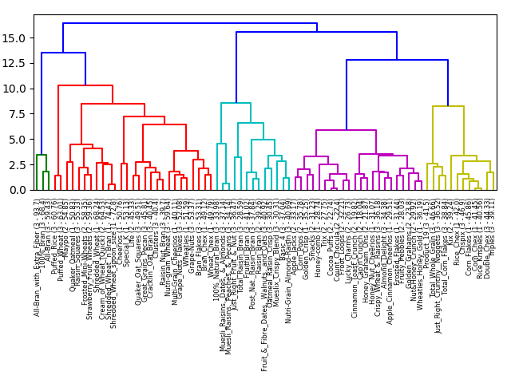

```python
from scipy.cluster.hierarchy import linkage, dendrogram

# Preparing linkage matrix
linkage_matrix = linkage(std_cereals, method='ward',metric='euclidean')

import matplotlib.pyplot as plt
%matplotlib notebook

fig, axs = plt.subplots()
dendrogram(linkage_matrix,labels=cereal_label.as_matrix())
plt.tight_layout()
plt.show()
```

```python
from sklearn.cluster import AgglomerativeClustering

## Instantiating object
agg_clust = AgglomerativeClustering(n_clusters=6, affinity='euclidean', linkage='ward')

## Training model and return class labels
agg_clusters = agg_clust.fit_predict(std_cereals)

## Label - Cluster
agg_result = pd.DataFrame({"label":cereal_label,"agg_cluster":agg_clusters}).sort_values('agg_cluster')
agg_result.head()
```

|  | agg_cluster | label |
| --- | --- | --- |
| 49 | 0 | Nutri-Grain_Almond-Raisin (3 - 40.69) |
| 1 | 0 | 100%_Natural_Bran (3 - 33.98) |
| 46 | 0 | Mueslix_Crispy_Blend (3 - 30.31) |
| 45 | 0 | Muesli_Raisins,_Peaches,_&_Pecans (3 - 34.14) |
| 44 | 0 | Muesli_Raisins,_Dates,_&_Almonds (3 - 37.14) |

## K-Means Clustering

**Parameter description**

n_clusters : The number of clusters to find.

tol : Relative tolerance with regards to inertia to declare convergence

n_init : Number of time the k-means algorithm will be run with different centroid seeds. The final results will be the best output of n_init consecutive runs in terms of inertia.

max_iter : max iterations of recomputing new cluster centroids

n_jobs : The number of jobs to use for the computation. This works by computing each of the n_init runs in parallel.

```python
from sklearn.cluster import KMeans
kmeans_object = KMeans(n_clusters=5, random_state=1240)
kmeans_object.fit(std_cereals)
kmeans_clusters = kmeans_object.predict(std_cereals)

kmeans_results = pd.DataFrame({"label":cereal_label,"kmeans_cluster":kmeans_clusters})
kmeans_results.head()
```

|  | kmeans_cluster | label |
| --- | --- | --- |
| 0 | 4 | 100%_Bran (3 - 68.4) |
| 1 | 2 | 100%_Natural_Bran (3 - 33.98) |
| 2 | 4 | All-Bran (3 - 59.43) |
| 3 | 4 | All-Bran_with_Extra_Fiber (3 - 93.7) |
| 4 | 2 | Almond_Delight (3 - 34.38) |

### Inspecting cluster centroids to understand average statistics of each cluster

```python
cluster_centroids = pd.DataFrame(standardizer.inverse_transform(kmeans_object.cluster_centers_),columns=cereals.columns)   ## Using inverse_transform to retrive actual values from standardized data
cluster_centroids.to_csv("best_kmeans_cluster_centroids.csv")
cluster_centroids
```

|  | calories | carbo | cups | fat | fiber | potass | protein | sodium | sugars | vitamins | weight |
| --- | --- | --- | --- | --- | --- | --- | --- | --- | --- | --- | --- |
| 0 | 135.000000 | 15.625000 | 0.758333 | 1.666667 | 3.541667 | 172.083333 | 3.166667 | 180.416667 | 10.916667 | 37.500000 | 1.287500 |
| 1 | 105.294118 | 19.294118 | 1.002941 | 0.529412 | 1.176471 | 62.352941 | 2.705882 | 237.058824 | 3.000000 | 42.647059 | 1.000000 |
| 2 | 108.529412 | 12.661765 | 0.782353 | 1.294118 | 1.397059 | 74.078431 | 2.058824 | 161.029412 | 9.411765 | 24.264706 | 1.000000 |
| 3 | 85.454545 | 15.800239 | 0.846364 | 0.272727 | 2.063636 | 93.060606 | 2.727273 | 8.636364 | 2.547847 | 9.090909 | 0.893636 |
| 4 | 63.333333 | 6.666667 | 0.386667 | 0.666667 | 11.000000 | 310.000000 | 4.000000 | 176.666667 | 3.666667 | 25.000000 | 1.000000 |

### How to select best K value for K-Means -> Silhouette Analysis

**Higher the silhouette score better the clustering**

*The silhouette value is a measure of how similar an object is to its own cluster (cohesion) compared to other clusters (separation). The silhouette ranges from −1 to +1, where a high value indicates that the object is well matched to its own cluster and poorly matched to neighboring clusters. If most objects have a high value, then the clustering configuration is appropriate. If many points have a low or negative value, then the clustering configuration may have too many or too few clusters.*

```
Automatically created module for IPython interactive environment
```

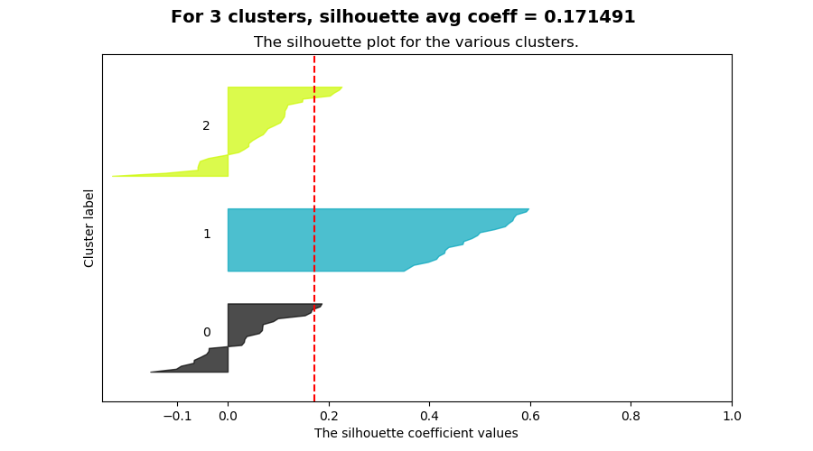

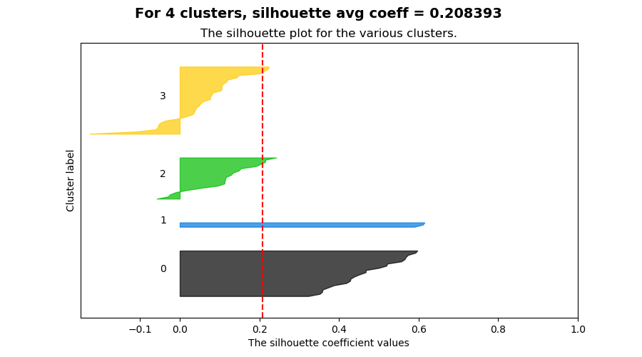

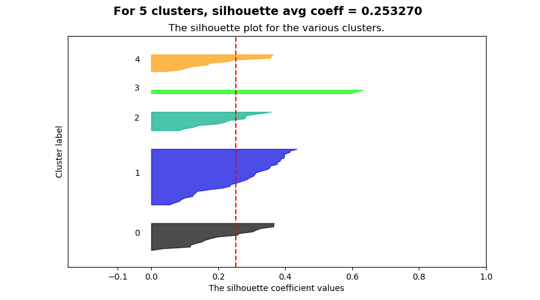

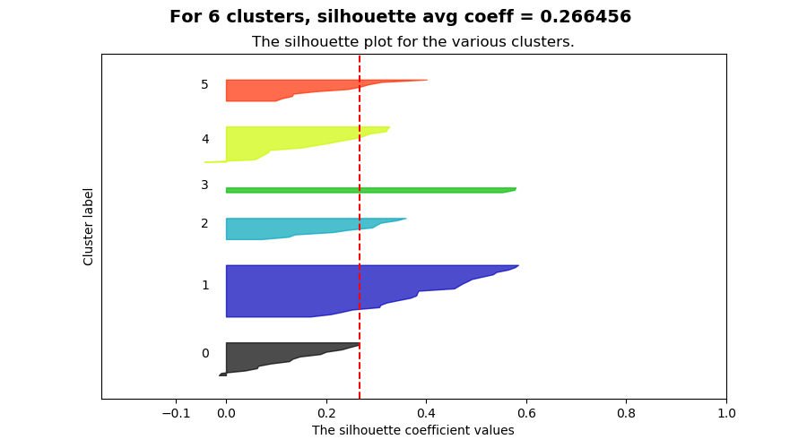

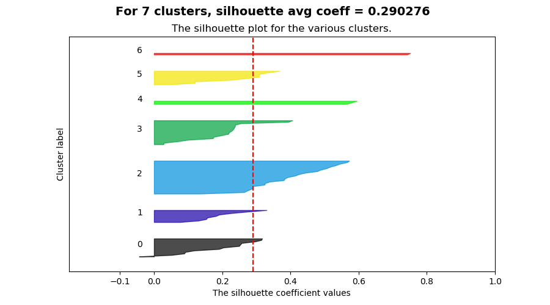

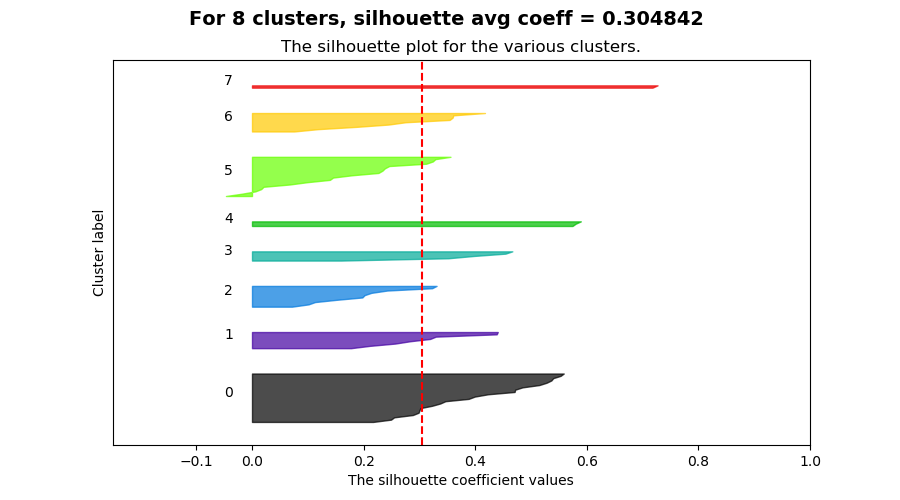

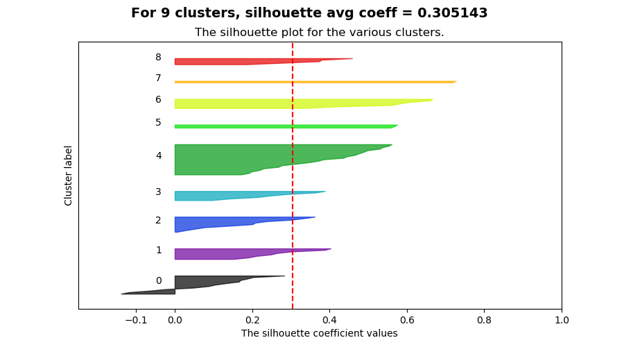

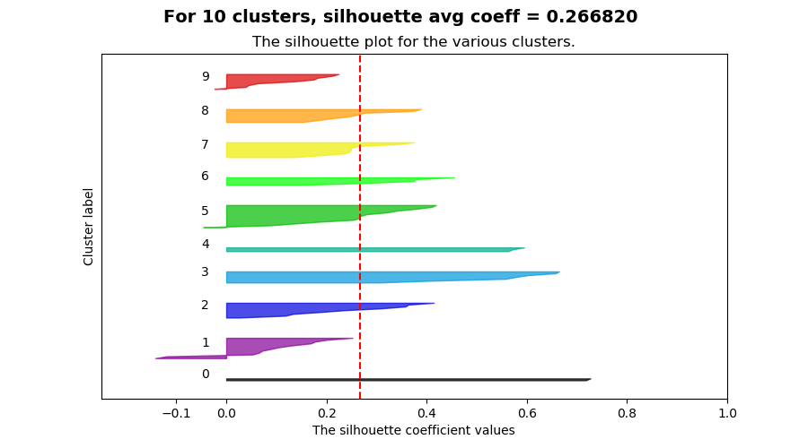

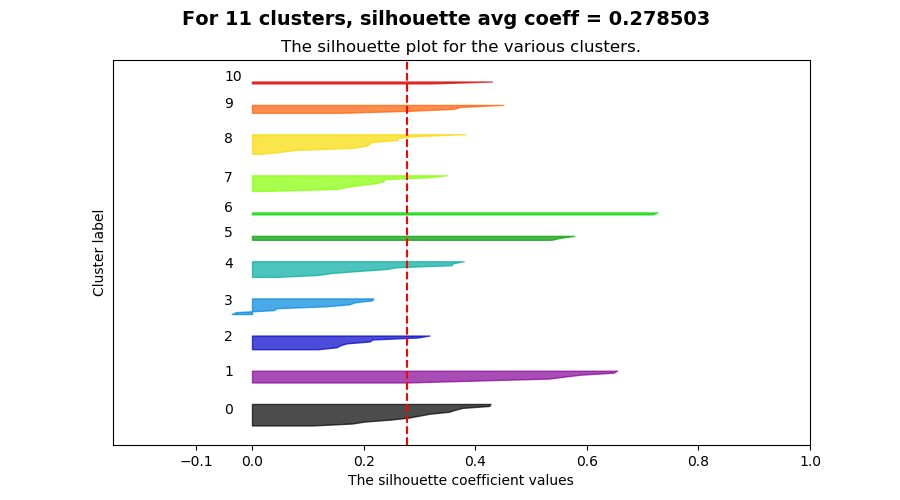

```python
## Standard plotting code copied from sklearn documentation.
## Just change "X_matrix" to the data of your choice

from __future__ import print_function

from sklearn.datasets import make_blobs
from sklearn.cluster import KMeans
from sklearn.metrics import silhouette_samples, silhouette_score

import matplotlib.pyplot as plt
import matplotlib.cm as cm
import numpy as np

print(__doc__)

### Just change this to your dataframe
X_matrix = std_cereals.as_matrix()

range_n_clusters = [3, 4, 5, 6, 7, 8, 9, 10, 11]

for n_clusters in range_n_clusters:
    # Create a subplot with 1 row and 1 column
    fig, (ax1) = plt.subplots(1, 1)
    fig.set_size_inches(9, 5)

    # The 1st subplot is the silhouette plot
    # The silhouette coefficient can range from -1, 1 but in this example all
    # lie within [-0.1, 1]
    ax1.set_xlim([-0.25, .5])
    # The (n_clusters+1)*10 is for inserting blank space between silhouette
    # plots of individual clusters, to demarcate them clearly.
    ax1.set_ylim([0, len(X_matrix) + (n_clusters + 1) * 10])

    # Initialize the clusterer with n_clusters value and a random generator
    # seed of 10 for reproducibility.
    clusterer = KMeans(n_clusters=n_clusters, random_state=10)
    cluster_labels = clusterer.fit_predict(X_matrix)

    # The silhouette_score gives the average value for all the samples.
    # This gives a perspective into the density and separation of the formed
    # clusters
    silhouette_avg = silhouette_score(X_matrix, cluster_labels)

    # Compute the silhouette scores for each sample
    sample_silhouette_values = silhouette_samples(X_matrix, cluster_labels)

    y_lower = 10
    for i in range(n_clusters):
        # Aggregate the silhouette scores for samples belonging to
        # cluster i, and sort them
        ith_cluster_silhouette_values = \
            sample_silhouette_values[cluster_labels == i]

        ith_cluster_silhouette_values.sort()

        size_cluster_i = ith_cluster_silhouette_values.shape[0]
        y_upper = y_lower + size_cluster_i

        color = cm.nipy_spectral(float(i) / n_clusters)
        ax1.fill_betweenx(np.arange(y_lower, y_upper),
                          0, ith_cluster_silhouette_values,
                          facecolor=color, edgecolor=color, alpha=0.7)

        # Label the silhouette plots with their cluster numbers at the middle
        ax1.text(-0.05, y_lower + 0.5 * size_cluster_i, str(i))

        # Compute the new y_lower for next plot
        y_lower = y_upper + 10  # 10 for the 0 samples

    ax1.set_title("The silhouette plot for the various clusters.")
    ax1.set_xlabel("The silhouette coefficient values")
    ax1.set_ylabel("Cluster label")

    # The vertical line for average silhouette score of all the values
    ax1.axvline(x=silhouette_avg, color="red", linestyle="--")

    ax1.set_yticks([])  # Clear the yaxis labels / ticks
    ax1.set_xticks([-0.1, 0, 0.2, 0.4, 0.6, 0.8, 1])

    plt.suptitle(("For %d clusters, silhouette avg coeff = %f " % (n_clusters,silhouette_avg)),
                 fontsize=14, fontweight='bold')
    plt.show()
```

### Note - Higher the silhouette score better the clustering.

```python
best_kmeans = KMeans(n_clusters=8, random_state=1240)
best_kmeans.fit(std_cereals)
best_kmeans_labels = best_kmeans.predict(std_cereals)
```

## Using PCA to visualize data

```python
from sklearn.decomposition import PCA
pca_obj = PCA(n_components=3).fit(std_cereals)
pca_train = pca_obj.transform(std_cereals)
print(pca_obj.explained_variance_ratio_)
print("Cumulative variance explained", np.sum(pca_obj.explained_variance_ratio_))
```

```
[ 0.27947468  0.2393557   0.15871109]
Cumulative variance explained 0.67754146804
```

## Interactive 3-D plot

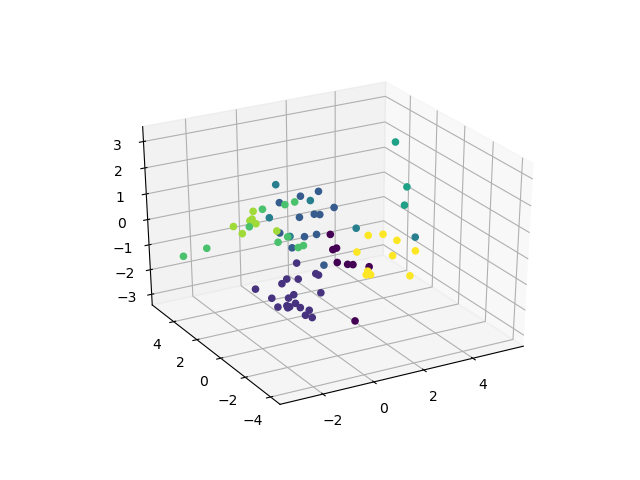

```python
from mpl_toolkits.mplot3d import Axes3D
fig = plt.figure()
ax = plt.axes(projection='3d')

ax.scatter(xs=pca_train[:,0], ys=pca_train[:,1], zs=pca_train[:,2],  c=best_kmeans.labels_, depthshade=False)
plt.show()
```

```python
cereals['best_kmeans_cluster'] = best_kmeans_labels
cereals.to_csv('cereal with cluster_label.csv')
```